# Overfitting the YOLOv8 Model

In this notebook, the goal is to test if the model can memorize the training data.

**Why overfit?**

- Verify setup — GPU, data loading, YOLO installation all working
- Sanity check — Confirms model can learn our data
- Debug annotations — If it still fails, labels might be wrong
- Baseline — Compare against non-overfit model

**How we overfit a model?**

- Use a small dataset, not too diverse, model will struggle to generalize (the model cannot learn underlaying pattern, just memorizes)
- use a smaller (YOLOv8 nano) model, which has fewer parameters and is more likely to memorize the data than YOLOv8 small
- Train for too many epochs (the model learns the noise)
- Larger batches (result in sharp minima in loss and fit training data perfectly, but generalize poorly)
- No dropout, early stopping or regularization (all neurons used and no penalization to high weights)
- No data augmentation (no added variety and increased dataset)
- Higher learning rate (to force the model to converge quickly, setting into a suboptimal local minimum)
- Freeze the early layers (responsible for general feature extraction, only fine-tuning the specialized layers)

```python
from google.colab import drive
# drive.flush_and_unmount()
drive.mount('/content/drive/')

%cd /content/drive/My Drive/FHNW/HS_25/DLBS/minichallenge_hs25_object_detection/MC
```

```
/content/drive/My Drive/FHNW/HS_25/DLBS/minichallenge_hs25_object_detection/MC
```

```python
from helpers import (
    load_roboflow_data,
    save_weights_to_drive,
    visualize_training_results,
    display_yolo_plots
)
```

## Load the Roboflow dataset

### 1. Normal training dataset

```python
import os
DATASET_PATH = 'Santa-10'
!ls -F {DATASET_PATH}/train/
```

```
images/  labels/  labels.cache
```

```python
!ls -F {DATASET_PATH}/train/images | head -n 5
```

```
00up-santa-1-48c8-mediumSquareAt3X_jpg.rf.c63c1265b432b4380d663df99cb615f5.jpg
0422a1dde5c95508deeddebb00907cee_jpg.rf.75a1fd574f32b7d9d1677b0e0c4e1370.jpg
0436409a-d7ef-45f2-a802-ed65013c3c9f_jpg.rf.a3cb0298a1236c0f58a7b87242d1df8c.jpg
06-RED-GREEN-GOLD_jpg.rf.84e7a157467eeb6d26f13cc1a4e77088.jpg
091222-santa-vmed-10a_webp.rf.f1ca685fb6b11acbe09d9fe31f980377.jpg
```

```python
!ls -F {DATASET_PATH}/valid/images | head -n 5
```

```
119_Santa_jpg.rf.be8a7963b1a920cd03f4895ad6547871.jpg
_127873954_microsoftteams-image-20_png.rf.d013f0217d7f7e594129b2fe95c7296e.jpg
127_Santa_jpg.rf.20736e3c77e95f245df7763627c07041.jpg
14italy-santa-dispatch01-mediumSquareAt3X_jpg.rf.6febce254def402c7d578ad63fca228e.jpg
151_Santa_jpg.rf.e8ed4ee507325f79aafbcaf480fbf704.jpg
```

### 2. Smaller dataset for overfitting

```python
!pip install roboflow -q
load_roboflow_data('dlbs-xi5zk', 'small_dataset-uvsxo', 3)
```

```
loading Roboflow workspace...
loading Roboflow project...

✅ Dataset downloaded to: /content/drive/MyDrive/FHNW/HS_25/DLBS/minichallenge_hs25_object_detection/MC/small_dataset-3
Dataset name: small_dataset
```

```
<roboflow.core.dataset.Dataset at 0x7f91771a84a0>
```

```python
# Dataset with 30 images, subset of the main dataset, low variability
# Check images in the small training set - should be different from the set above
DATASET_OVERFIT = 'small_dataset-3'
# Count the number of images in the small dataset
!ls -1 {DATASET_OVERFIT}/train/images | wc -l
```

```
30
```

```python
# Check 'validation' images, should be the same as for the normal Santa-8 dataset
!ls -F {DATASET_OVERFIT}/valid/images | head -n 5
```

```
119_Santa_jpg.rf.be8a7963b1a920cd03f4895ad6547871.jpg
_127873954_microsoftteams-image-20_png.rf.d013f0217d7f7e594129b2fe95c7296e.jpg
127_Santa_jpg.rf.20736e3c77e95f245df7763627c07041.jpg
14italy-santa-dispatch01-mediumSquareAt3X_jpg.rf.6febce254def402c7d578ad63fca228e.jpg
151_Santa_jpg.rf.e8ed4ee507325f79aafbcaf480fbf704.jpg
```

```python
!nvidia-smi
```

```
Sat Jan 10 12:21:26 2026
+-----------------------------------------------------------------------------------------+
| NVIDIA-SMI 550.54.15              Driver Version: 550.54.15      CUDA Version: 12.4     |
|-----------------------------------------+------------------------+----------------------+
| GPU  Name                 Persistence-M | Bus-Id          Disp.A | Volatile Uncorr. ECC |
| Fan  Temp   Perf          Pwr:Usage/Cap |           Memory-Usage | GPU-Util  Compute M. |
|                                         |                        |               MIG M. |
|=========================================+========================+======================|
|   0  NVIDIA A100-SXM4-80GB          Off |   00000000:00:05.0 Off |                    0 |
| N/A   35C    P0             54W /  400W |       0MiB /  81920MiB |      0%      Default |
|                                         |                        |             Disabled |
+-----------------------------------------+------------------------+----------------------+

+-----------------------------------------------------------------------------------------+
| Processes:                                                                              |
|  GPU   GI   CI        PID   Type   Process name                              GPU Memory |
|        ID   ID                                                               Usage      |
|=========================================================================================|
|  No running processes found                                                             |
+-----------------------------------------------------------------------------------------+
```

## Install Dependencies & Authentication (Ultralitycs and Weights & Biases)

```python
# Install YOLO library
!pip install ultralytics -q

from IPython import display
display.clear_output()

# prevent ultralytics from tracking activity
!yolo settings sync=False

import ultralytics
ultralytics.checks()
```

```
Ultralytics 8.3.252 🚀 Python-3.12.12 torch-2.9.0+cu126 CUDA:0 (NVIDIA A100-SXM4-80GB, 81222MiB)
Setup complete ✅ (12 CPUs, 167.1 GB RAM, 38.5/235.7 GB disk)
```

```python
# W&B login
!pip install wandb -q
import wandb
from google.colab import userdata
WANDB_API_KEY = userdata.get('WANDB_API_KEY')
wandb.login(key=WANDB_API_KEY)
```

## Load model and model metadata about the datasets

```python
import os
import shutil
from ultralytics import YOLO

# --- LOAD MODEL FROM CACHE ---
MODEL_NAME = 'yolov8n.pt'
DRIVE_PATH = '/content/drive/My Drive/FHNW/HS_25/DLBS/minichallenge_hs25_object_detection/MC/models_cache/'
MODEL_PATH = os.path.join(DRIVE_PATH, MODEL_NAME) # Nano

os.makedirs(DRIVE_PATH, exist_ok=True)

if os.path.exists(MODEL_PATH):
    print(f"✅ Loading from cache: {MODEL_PATH}")
    model = YOLO(MODEL_PATH)
else:
    print(f"⬇️ Downloading {MODEL_NAME}...")
    model = YOLO(MODEL_NAME)
    source = MODEL_NAME if os.path.exists(MODEL_NAME) else os.path.expanduser(f'~/.config/ultralytics/{MODEL_NAME}')
    if os.path.exists(source):
        shutil.copyfile(source, MODEL_PATH)
        if source == MODEL_NAME:
            os.remove(MODEL_NAME)
        print(f"✅ Saved to Drive: {MODEL_PATH}")

# Set up data location
dataset_yaml = f'{DATASET_PATH}/data.yaml'
# Set up data for minimal train dataset
dataset_yaml_3 = f'{DATASET_OVERFIT}/data.yaml'
```

```
✅ Loading from cache: /content/drive/My Drive/FHNW/HS_25/DLBS/minichallenge_hs25_object_detection/MC/models_cache/yolov8n.pt
```

**Logical architecture of the YOLOv8 nano model, high-level modules (Backbone, Neck, and Head):**

- Backbone (0-9): 10 major blocks.
- Neck (10-21): 12 major blocks for upsampling and fusion.
- Head (22): 1 final block for detection.

The YOLOv8n model is a high-efficiency detector. Its 3M parameters and 8.1 GFLOPs make it ideal for real-time inference. The architecture utilizes a Backbone for feature extraction, a PANet Neck for multi-scale feature fusion that combines high-level semantic info with low-level geometric info, and a Decoupled Head for final object localization and classification.

**Model summary (fused):**

- 72 layers,
- 3,005,843 parameters,
- 8.1 GFLOPs computational complexity

```python
MODEL_N_PATH = MODEL_PATH
model = YOLO(MODEL_N_PATH)
print(model.model)
```

```
DetectionModel(
  (model): Sequential(
    (0): Conv(
      (conv): Conv2d(3, 16, kernel_size=(3, 3), stride=(2, 2), padding=(1, 1), bias=False)
      (bn): BatchNorm2d(16, eps=0.001, momentum=0.03, affine=True, track_running_stats=True)
      (act): SiLU(inplace=True)
    )
    (1): Conv(
      (conv): Conv2d(16, 32, kernel_size=(3, 3), stride=(2, 2), padding=(1, 1), bias=False)
      (bn): BatchNorm2d(32, eps=0.001, momentum=0.03, affine=True, track_running_stats=True)
      (act): SiLU(inplace=True)
    )
    (2): C2f(
      (cv1): Conv(
        (conv): Conv2d(32, 32, kernel_size=(1, 1), stride=(1, 1), bias=False)
        (bn): BatchNorm2d(32, eps=0.001, momentum=0.03, affine=True, track_running_stats=True)
        (act): SiLU(inplace=True)
      )
      (cv2): Conv(
        (conv): Conv2d(48, 32, kernel_size=(1, 1), stride=(1, 1), bias=False)
        (bn): BatchNorm2d(32, eps=0.001, momentum=0.03, affine=True, track_running_stats=True)
        (act): SiLU(inplace=True)
      )
      (m): ModuleList(
        (0): Bottleneck(
          (cv1): Conv(
            (conv): Conv2d(16, 16, kernel_size=(3, 3), stride=(1, 1), padding=(1, 1), bias=False)
            (bn): BatchNorm2d(16, eps=0.001, momentum=0.03, affine=True, track_running_stats=True)
            (act): SiLU(inplace=True)
          )
          (cv2): Conv(
            (conv): Conv2d(16, 16, kernel_size=(3, 3), stride=(1, 1), padding=(1, 1), bias=False)
            (bn): BatchNorm2d(16, eps=0.001, momentum=0.03, affine=True, track_running_stats=True)
            (act): SiLU(inplace=True)
          )
        )
      )
    )
    (3): Conv(
      (conv): Conv2d(32, 64, kernel_size=(3, 3), stride=(2, 2), padding=(1, 1), bias=False)
```

[output cut: 298 more lines]

```
          )
          (1): Conv(
            (conv): Conv2d(80, 80, kernel_size=(3, 3), stride=(1, 1), padding=(1, 1), bias=False)
            (bn): BatchNorm2d(80, eps=0.001, momentum=0.03, affine=True, track_running_stats=True)
            (act): SiLU(inplace=True)
          )
          (2): Conv2d(80, 80, kernel_size=(1, 1), stride=(1, 1))
        )
      )
      (dfl): DFL(
        (conv): Conv2d(16, 1, kernel_size=(1, 1), stride=(1, 1), bias=False)
      )
    )
  )
)
```

**Setting up training parameters**

- *data*: Points to the dataset YAML file, which contains paths to images and labels, along with the number of classes and class names.
- *epochs*: The number of times the entire dataset will be used in training.
- *batch_size*: Defines how many images will be processed at once during training.
- *imgsz*: Image size to resize each input image to during training (common choices: 320, 416, 640).
- *lr0* and *lr1*: Learning rates for the initial and final stages of training (useful for setting up learning rate schedules).
- *momentum*: Momentum of the optimizer (helps accelerate the training process).
- *optimizer*: We can choose between Adam and SGD for the optimizer, with Adam being commonly used for object detection models.
- *project*: The project name in WandB where the run data will be logged.
- *tags*: Tags are used to categorize runs in WandB.
- *verbose*: Set to True for detailed logs during training.
- *save*: Ensures training logs and results are saved during the run.
- *exist_ok*: If set to True, it will overwrite an existing run with the same name.
- *img_weights*: If using weighted images (optional).

**Freezing layers**

Early layers (backbone) learn general features (edges, textures, basic shapes). As they are already well-trained on large datasets like COCO or ImageNet they transfer well across datasets. Freezing them prevents learning dataset-specific generalizable features.

Deep layers (neck/head) learn task-specific features and detection patterns to make object localization and classification. They adapt to our specific dataset and training these allows the model to memorize the specific examples.

For a 72-layer YOLO8 model:

- Layers 0-10: Freeze (early backbone - basic feature extraction)
- Layers 11-71: Train (deeper backbone, neck, and head - memorization happens here)

```python
# Training parameters for each run, different freezing, batch size, dataset size
# Normal dataset, run 1 config, YOLO NANO
baseline_config_1 = {
    'data': dataset_yaml,
    'epochs': 200,
    'imgsz': 512,
    'batch': 84,              # Larger batch
    'patience': 0,            # No early stopping
    'device': 0,
    'augment': False,         # No augmentation
    'lr0': 0.01,              # Default learning rate
    'momentum': 0.9,
    'weight_decay': 0.0,      # No L2 regularization
    'dropout': 0.0,           # No dropout
    'verbose': True,
    'save': True,
    'project': 'runs/overfit',  # Ultralytics project folder
    'name': 'baseline_run_1',   # Ultralytics run folder name
    'val': True,                # Validation is used
    'exist_ok': True
}

# Normal dataset, larger model YOLO S, more params
baseline_config_2 = {
    'data': dataset_yaml,
    'epochs': 250,            # Large number of epochs, training too long
    'imgsz': 512,
    'batch': 32,
    'patience': 0,
    'device': 0,
    'augment': False,
    'close_mosaic': 0,
    'freeze': 19,             # freeze the first 20 layers
    'lr0': 0.05,              # Higher learning rate
    'momentum': 0.9,
    'weight_decay': 0.0,
    'dropout': 0.0,
    'verbose': True,
    'save': True,
    'project': 'runs/overfit',
    'name': 'baseline_run_2',
    'val': True,
    'exist_ok': True
}

# Small dataset + N model
overfitting_config_3 = {
    'data': dataset_yaml_3,
    'epochs': 250,
    'imgsz': 512,
    'batch': 15,              # Batch size = 1/2 dataset
    'patience': 0,            # No early stopping
    'device': 0,
    'augment': False,         # No augmentation
    'close_mosaic': 0,        # Disable Mosaic augmentation at the beginning
    'freeze': 9,              # freeze the first 10 layers
    'lr0': 0.01,              # learning rate was too high, to try to make it memorize
    'momentum': 0.9,
    'weight_decay': 0.0,      # No L2 regularization
    'dropout': 0.0,           # No dropout
    # 'optimizer': 'Adam',    # No optimizer
    'verbose': True,
    'save': True,
    'project': 'runs/overfit', # Ultralytics project folder
    'name': 'overfit_run_3', # Ultralytics run folder name
    'val': True, # Ensure validation is used
    'exist_ok': True
}

# Small dataset + S model
overfitting_config_4 = {
    'data': dataset_yaml_3,
    'epochs': 250,            # Large number of epochs, training too long
    'imgsz': 512,
    'batch': 15,              # Batch size = 1/2 dataset
    'patience': 0,            # No early stopping
    'device': 0,
    'augment': False,         # No augmentation
    'close_mosaic': 0,        # Disable Mosaic augmentation at the beginning
    'freeze': 20,              # freeze the first 10 layers
    'lr0': 0.01,              # learning rate was too high, to try to make it memorize
    'momentum': 0.9,
    'weight_decay': 0.0,      # No L2 regularization
    'dropout': 0.0,           # No dropout
    # 'optimizer': 'Adam',    # No optimizer
    'verbose': True,
    'save': True,
    'project': 'runs/overfit', # Ultralytics project folder
    'name': 'overfit_run_4', # Ultralytics run folder name
    'val': True, # Ensure validation is used
    'exist_ok': True
}
```

```python
# --- RUN 1
model = YOLO(MODEL_N_PATH)

# No image augmentation, no regularizaton
# Normal sized training dataset
# --- W&B INITIALIZATION ---
wandb.init(
    project='yolov8_santa_train',
    entity='katai',
    config=baseline_config_1,
    name='overfit_run_1'
)

# --- TRAIN ---
print("🚀 Starting training (designed to overfit) ...")
results = model.train(**baseline_config_1)

# --- CLEANUP ---
wandb.finish()
print("✅ Training complete!")
```

Tracking run with wandb version 0.23.1

Run data is saved locally in `/content/drive/My Drive/FHNW/HS_25/DLBS/minichallenge_hs25_object_detection/MC/wandb/run-20260110_125833-qjt6m9l2`

Syncing run **[overfit_run_1](https://wandb.ai/katai/yolov8_santa_train/runs/qjt6m9l2)** to [Weights & Biases](https://wandb.ai/katai/yolov8_santa_train) ([docs](https://wandb.me/developer-guide))

View project at https://wandb.ai/katai/yolov8_santa_train

View run at https://wandb.ai/katai/yolov8_santa_train/runs/qjt6m9l2

```
🚀 Starting training (designed to overfit) ...
Ultralytics 8.3.251 🚀 Python-3.12.12 torch-2.9.0+cu126 CUDA:0 (NVIDIA A100-SXM4-80GB, 81222MiB)
engine/trainer: agnostic_nms=False, amp=True, augment=False, auto_augment=randaugment, batch=84, bgr=0.0, box=7.5, cache=False, cfg=None, classes=None, close_mosaic=10, cls=0.5, compile=False, conf=None, copy_paste=0.0, copy_paste_mode=flip, cos_lr=False, cutmix=0.0, data=Santa-10/data.yaml, degrees…
Overriding model.yaml nc=80 with nc=1

                   from  n    params  module                                       arguments
  0                  -1  1       464  ultralytics.nn.modules.conv.Conv             [3, 16, 3, 2]
  1                  -1  1      4672  ultralytics.nn.modules.conv.Conv             [16, 32, 3, 2]
  2                  -1  1      7360  ultralytics.nn.modules.block.C2f             [32, 32, 1, True]
  3                  -1  1     18560  ultralytics.nn.modules.conv.Conv             [32, 64, 3, 2]
  4                  -1  2     49664  ultralytics.nn.modules.block.C2f             [64, 64, 2, True]
  5                  -1  1     73984  ultralytics.nn.modules.conv.Conv             [64, 128, 3, 2]
  6                  -1  2    197632  ultralytics.nn.modules.block.C2f             [128, 128, 2, True]
  7                  -1  1    295424  ultralytics.nn.modules.conv.Conv             [128, 256, 3, 2]
  8                  -1  1    460288  ultralytics.nn.modules.block.C2f             [256, 256, 1, True]
  9                  -1  1    164608  ultralytics.nn.modules.block.SPPF            [256, 256, 5]
 10                  -1  1         0  torch.nn.modules.upsampling.Upsample         [None, 2, 'nearest']
 11             [-1, 6]  1         0  ultralytics.nn.modules.conv.Concat           [1]
 12                  -1  1    148224  ultralytics.nn.modules.block.C2f             [384, 128, 1]
 13                  -1  1         0  torch.nn.modules.upsampling.Upsample         [None, 2, 'nearest']
 14             [-1, 4]  1         0  ultralytics.nn.modules.conv.Concat           [1]
 15                  -1  1     37248  ultralytics.nn.modules.block.C2f             [192, 64, 1]
 16                  -1  1     36992  ultralytics.nn.modules.conv.Conv             [64, 64, 3, 2]
 17            [-1, 12]  1         0  ultralytics.nn.modules.conv.Concat           [1]
 18                  -1  1    123648  ultralytics.nn.modules.block.C2f             [192, 128, 1]
 19                  -1  1    147712  ultralytics.nn.modules.conv.Conv             [128, 128, 3, 2]
 20             [-1, 9]  1         0  ultralytics.nn.modules.conv.Concat           [1]
 21                  -1  1    493056  ultralytics.nn.modules.block.C2f             [384, 256, 1]
 22        [15, 18, 21]  1    751507  ultralytics.nn.modules.head.Detect           [1, [64, 128, 256]]
Model summary: 129 layers, 3,011,043 parameters, 3,011,027 gradients, 8.2 GFLOPs

Transferred 319/355 items from pretrained weights
Freezing layer 'model.22.dfl.conv.weight'
AMP: running Automatic Mixed Precision (AMP) checks...
AMP: checks passed ✅
train: Fast image access ✅ (ping: 0.9±0.7 ms, read: 19.7±9.6 MB/s, size: 32.3 KB)
train: Scanning /content/drive/My Drive/FHNW/HS_25/DLBS/minichallenge_hs25_object_detection/MC/Santa-10/train/labels.cache... 700 images, 327 backgrounds, 0 corrupt: 100% ━━━━━━━━━━━━ 700/700 439.1Kit/s 0.0s
albumentations: Blur(p=0.01, blur_limit=(3, 7)), MedianBlur(p=0.01, blur_limit=(3, 7)), ToGray(p=0.01, method='weighted_average', num_output_channels=3), CLAHE(p=0.01, clip_limit=(1.0, 4.0), tile_grid_size=(8, 8))
val: Fast image access ✅ (ping: 71.0±156.6 ms, read: 3.6±3.2 MB/s, size: 31.2 KB)
val: Scanning /content/drive/My Drive/FHNW/HS_25/DLBS/minichallenge_hs25_object_detection/MC/Santa-10/valid/labels... 155 images, 54 backgrounds, 0 corrupt: 100% ━━━━━━━━━━━━ 155/155 136.4it/s 1.1s
```

[output cut: 1007 more lines]

```
    200/200       8.3G     0.3011      0.259     0.9345         35        512: 100% ━━━━━━━━━━━━ 9/9 5.7it/s 1.6s
                 Class     Images  Instances      Box(P          R      mAP50  mAP50-95): 100% ━━━━━━━━━━━━ 1/1 2.6it/s 0.4s
                   all        155        105      0.874      0.859      0.886      0.651

200 epochs completed in 0.136 hours.
Optimizer stripped from /content/drive/My Drive/FHNW/HS_25/DLBS/minichallenge_hs25_object_detection/MC/runs/detect/runs/overfit/baseline_run_1/weights/last.pt, 6.2MB
Optimizer stripped from /content/drive/My Drive/FHNW/HS_25/DLBS/minichallenge_hs25_object_detection/MC/runs/detect/runs/overfit/baseline_run_1/weights/best.pt, 6.2MB

Validating /content/drive/My Drive/FHNW/HS_25/DLBS/minichallenge_hs25_object_detection/MC/runs/detect/runs/overfit/baseline_run_1/weights/best.pt...
Ultralytics 8.3.251 🚀 Python-3.12.12 torch-2.9.0+cu126 CUDA:0 (NVIDIA A100-SXM4-80GB, 81222MiB)
Model summary (fused): 72 layers, 3,005,843 parameters, 0 gradients, 8.1 GFLOPs
                 Class     Images  Instances      Box(P          R      mAP50  mAP50-95): 100% ━━━━━━━━━━━━ 1/1 2.4it/s 0.4s
                   all        155        105      0.817      0.876      0.891      0.666
Speed: 0.1ms preprocess, 0.3ms inference, 0.0ms loss, 0.7ms postprocess per image
Results saved to /content/drive/My Drive/FHNW/HS_25/DLBS/minichallenge_hs25_object_detection/MC/runs/detect/runs/overfit/baseline_run_1
```

View run **overfit_run_1** at: https://wandb.ai/katai/yolov8_santa_train/runs/qjt6m9l2  
View project at: https://wandb.ai/katai/yolov8_santa_train  
Synced 5 W&B file(s), 0 media file(s), 0 artifact file(s) and 0 other file(s)

Find logs at: `./wandb/run-20260110_125833-qjt6m9l2/logs`

```
✅ Training complete!
```

```python
#  --- CONFIGURATION ---
DRIVE_MODEL_DIR = 'yolov8_results/'
RUNS_DIR = 'runs/detect/runs/overfit/baseline_run_1' # Ultralytics default save path
BEST_WEIGHTS_FILENAME = 'best_baseline_1.pt'
OUTPUT_WEIGHTS_NAME = 'weights_baseline_1.pt'

# Ensure the Google Drive target directory exists
os.makedirs(DRIVE_MODEL_DIR, exist_ok=True)
# ---------------------
```

```python
# --- SAVE WEIGHTS TO GOOGLE DRIVE ---
save_weights_to_drive(RUNS_DIR, DRIVE_MODEL_DIR, BEST_WEIGHTS_FILENAME, OUTPUT_WEIGHTS_NAME)
```

```
✅ Best weights saved: best_baseline_1.pt
✅ Last weights saved: weights_baseline_1.pt
```

## Monitoring Model Training

**1. Core Loss Metrics (Error Monitoring)**

Primary objective is minimizing errors. The metrics are calculated for the training and validation splits at every step/epoch.

- *Box Loss (box_loss)*: How accurately the model predicts the bounding boxes' location and size? A lower value => better localization.
- *Classification Loss (cls_loss)*: How accurately the model predicts the class label (Santa) inside the box? A lower value => better classification.
- *D-Loss (dfl_loss)*: Distribution Focal Loss. How YOLOv8 (specifically its anchor-free head) models the bounding box as a probability distribution. A lower value => a more precise box boundary prediction.

**2. Standard Object Detection Metrics**

These metrics quantify the model's performance on the validation set after each epoch. They are the most important indicators of model quality.

- *Precision (P)*: The proportion of positive predictions that were actually correct. High precision means fewer false alarms.
- *Recall (R)*: The proportion of actual positive instances that were correctly identified. High recall ensures that you are catching as many "Santas" as possible, reducing the number of missed objects.
- *mean Average Precision (mAP)*: The single most important metric. It measures the quality of both detection (Precision and Recall) and localization across all classes and various confidence thresholds.
  - mAP@[0.5]: The mAP calculated at an Intersection over Union (IoU) threshold of 0.5 (a "loose" correct detection).
  - mAP@[0.5:0.95]: The average mAP calculated across IoU thresholds from 0.5 to 0.95 in 0.05 increments (a "strict" overall quality measure).

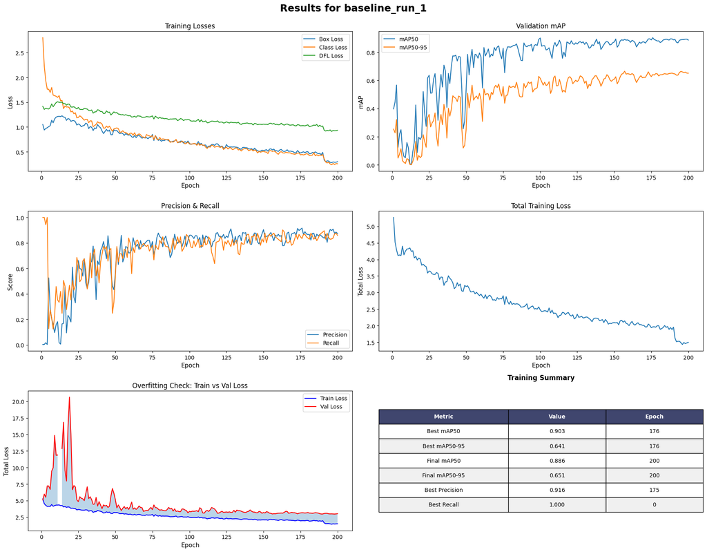

```
============================================================
📈 DETAILED TRAINING STATISTICS
============================================================
Total Epochs: 200

🎯 Best mAP50: 0.9032 (Epoch 175)
🎯 Best mAP50-95: 0.6654 (Epoch 156)

📊 Final Metrics:
   mAP50: 0.8865
   mAP50-95: 0.6512
   Precision: 0.8740
   Recall: 0.8588
============================================================
```

```python
import pandas as pd
import matplotlib.pyplot as plt

# Run 1
visualize_training_results(RUNS_DIR)
```

We want to find as many Santas as possible and miss as few as possible. Of all "Santa" predictions, 87.4% are correct (low false positives), which shows we are on the right track. Model is confident - when it says "Santa", it's usually right. There is no bias toward over/under-detection. However, ~86% recall means ~14% of Santas are not detected.

At IoU threshold 0.5 we correctly detect 88.7% of Santas with proper bounding boxes. The stricter IoU threshold (0.5 to 0.95) is still 65% accurate. However, the small gap between best and final mAP50 (90.3% → 88.7%) indicates stable training, with a bit of overfitting.

To assess if the model is overfitting, we compare the gap between Train Loss (How well it does on the training set?) and and Validation loss (How well it generalizes to unseen data?). In our case, val loss is higher than train loss (gap of ~1-2), so the model is memorizing training data slightly.

```python
# A larger model
MODEL_NAME = 'yolov8s.pt' #  YOLOv8-Small
DRIVE_PATH = 'models_cache/'
MODEL_S_PATH = os.path.join(DRIVE_PATH, MODEL_NAME)
model = YOLO(MODEL_S_PATH)
```

YOLOv8-Small has better potential for memorizing the data due to its larger size, more parameters, and higher capacity for learning complex features.

```python
# --- RUN 2: frozen backbone
# No augmentation, no regularization, but frozen early layers
# Still large train dataset
# --- W&B INITIALIZATION ---
wandb.init(
    project='yolov8_santa_train',
    entity='katai',
    config=baseline_config_2,
    name='baseline_run_2'
)

# --- TRAIN ---
print("🚀 Starting training (designed to overfit) ...")
results = model.train(**baseline_config_2)

# --- CLEANUP ---
wandb.finish()
print("✅ Training complete!")
```

Tracking run with wandb version 0.23.1

Run data is saved locally in `/content/drive/My Drive/FHNW/HS_25/DLBS/minichallenge_hs25_object_detection/MC/wandb/run-20260110_131815-040vvjcb`

Syncing run **[baseline_run_2](https://wandb.ai/katai/yolov8_santa_train/runs/040vvjcb)** to [Weights & Biases](https://wandb.ai/katai/yolov8_santa_train) ([docs](https://wandb.me/developer-guide))

View project at https://wandb.ai/katai/yolov8_santa_train

View run at https://wandb.ai/katai/yolov8_santa_train/runs/040vvjcb

```
🚀 Starting training (designed to overfit) ...
Ultralytics 8.3.251 🚀 Python-3.12.12 torch-2.9.0+cu126 CUDA:0 (NVIDIA A100-SXM4-80GB, 81222MiB)
engine/trainer: agnostic_nms=False, amp=True, augment=False, auto_augment=randaugment, batch=32, bgr=0.0, box=7.5, cache=False, cfg=None, classes=None, close_mosaic=0, cls=0.5, compile=False, conf=None, copy_paste=0.0, copy_paste_mode=flip, cos_lr=False, cutmix=0.0, data=Santa-10/data.yaml, degrees=…
Overriding model.yaml nc=80 with nc=1

                   from  n    params  module                                       arguments
  0                  -1  1       928  ultralytics.nn.modules.conv.Conv             [3, 32, 3, 2]
  1                  -1  1     18560  ultralytics.nn.modules.conv.Conv             [32, 64, 3, 2]
  2                  -1  1     29056  ultralytics.nn.modules.block.C2f             [64, 64, 1, True]
  3                  -1  1     73984  ultralytics.nn.modules.conv.Conv             [64, 128, 3, 2]
  4                  -1  2    197632  ultralytics.nn.modules.block.C2f             [128, 128, 2, True]
  5                  -1  1    295424  ultralytics.nn.modules.conv.Conv             [128, 256, 3, 2]
  6                  -1  2    788480  ultralytics.nn.modules.block.C2f             [256, 256, 2, True]
  7                  -1  1   1180672  ultralytics.nn.modules.conv.Conv             [256, 512, 3, 2]
  8                  -1  1   1838080  ultralytics.nn.modules.block.C2f             [512, 512, 1, True]
  9                  -1  1    656896  ultralytics.nn.modules.block.SPPF            [512, 512, 5]
 10                  -1  1         0  torch.nn.modules.upsampling.Upsample         [None, 2, 'nearest']
 11             [-1, 6]  1         0  ultralytics.nn.modules.conv.Concat           [1]
 12                  -1  1    591360  ultralytics.nn.modules.block.C2f             [768, 256, 1]
 13                  -1  1         0  torch.nn.modules.upsampling.Upsample         [None, 2, 'nearest']
 14             [-1, 4]  1         0  ultralytics.nn.modules.conv.Concat           [1]
 15                  -1  1    148224  ultralytics.nn.modules.block.C2f             [384, 128, 1]
 16                  -1  1    147712  ultralytics.nn.modules.conv.Conv             [128, 128, 3, 2]
 17            [-1, 12]  1         0  ultralytics.nn.modules.conv.Concat           [1]
 18                  -1  1    493056  ultralytics.nn.modules.block.C2f             [384, 256, 1]
 19                  -1  1    590336  ultralytics.nn.modules.conv.Conv             [256, 256, 3, 2]
 20             [-1, 9]  1         0  ultralytics.nn.modules.conv.Concat           [1]
 21                  -1  1   1969152  ultralytics.nn.modules.block.C2f             [768, 512, 1]
 22        [15, 18, 21]  1   2116435  ultralytics.nn.modules.head.Detect           [1, [128, 256, 512]]
Model summary: 129 layers, 11,135,987 parameters, 11,135,971 gradients, 28.6 GFLOPs

Transferred 349/355 items from pretrained weights
Freezing layer 'model.0.conv.weight'
Freezing layer 'model.0.bn.weight'
Freezing layer 'model.0.bn.bias'
Freezing layer 'model.1.conv.weight'
Freezing layer 'model.1.bn.weight'
Freezing layer 'model.1.bn.bias'
Freezing layer 'model.2.cv1.conv.weight'
Freezing layer 'model.2.cv1.bn.weight'
```

[output cut: 1374 more lines]

```
    250/250      2.49G     0.4503     0.4073     0.9939         36        512: 100% ━━━━━━━━━━━━ 22/22 11.2it/s 2.0s
                 Class     Images  Instances      Box(P          R      mAP50  mAP50-95): 100% ━━━━━━━━━━━━ 3/3 5.4it/s 0.6s
                   all        155        105      0.847      0.752      0.825      0.603

250 epochs completed in 0.202 hours.
Optimizer stripped from /content/drive/My Drive/FHNW/HS_25/DLBS/minichallenge_hs25_object_detection/MC/runs/detect/runs/overfit/baseline_run_2/weights/last.pt, 22.5MB
Optimizer stripped from /content/drive/My Drive/FHNW/HS_25/DLBS/minichallenge_hs25_object_detection/MC/runs/detect/runs/overfit/baseline_run_2/weights/best.pt, 22.5MB

Validating /content/drive/My Drive/FHNW/HS_25/DLBS/minichallenge_hs25_object_detection/MC/runs/detect/runs/overfit/baseline_run_2/weights/best.pt...
Ultralytics 8.3.251 🚀 Python-3.12.12 torch-2.9.0+cu126 CUDA:0 (NVIDIA A100-SXM4-80GB, 81222MiB)
Model summary (fused): 72 layers, 11,125,971 parameters, 0 gradients, 28.4 GFLOPs
                 Class     Images  Instances      Box(P          R      mAP50  mAP50-95): 100% ━━━━━━━━━━━━ 3/3 3.5it/s 0.9s
                   all        155        105       0.86      0.759      0.822      0.618
Speed: 0.1ms preprocess, 0.6ms inference, 0.0ms loss, 1.2ms postprocess per image
Results saved to /content/drive/My Drive/FHNW/HS_25/DLBS/minichallenge_hs25_object_detection/MC/runs/detect/runs/overfit/baseline_run_2
```

View run **baseline_run_2** at: https://wandb.ai/katai/yolov8_santa_train/runs/040vvjcb  
View project at: https://wandb.ai/katai/yolov8_santa_train  
Synced 5 W&B file(s), 0 media file(s), 0 artifact file(s) and 0 other file(s)

Find logs at: `./wandb/run-20260110_131815-040vvjcb/logs`

```
✅ Training complete!
```

```python
# --- CONFIGURATION ---
RUNS_DIR = 'runs/detect/runs/overfit/baseline_run_2'
BEST_WEIGHTS_FILENAME = 'best_baseline_2.pt'
OUTPUT_WEIGHTS_NAME = 'weights_baseline_2.pt'

save_weights_to_drive(RUNS_DIR, DRIVE_MODEL_DIR, BEST_WEIGHTS_FILENAME, OUTPUT_WEIGHTS_NAME)
```

```
✅ Best weights saved: best_baseline_2.pt
✅ Last weights saved: weights_baseline_2.pt
```

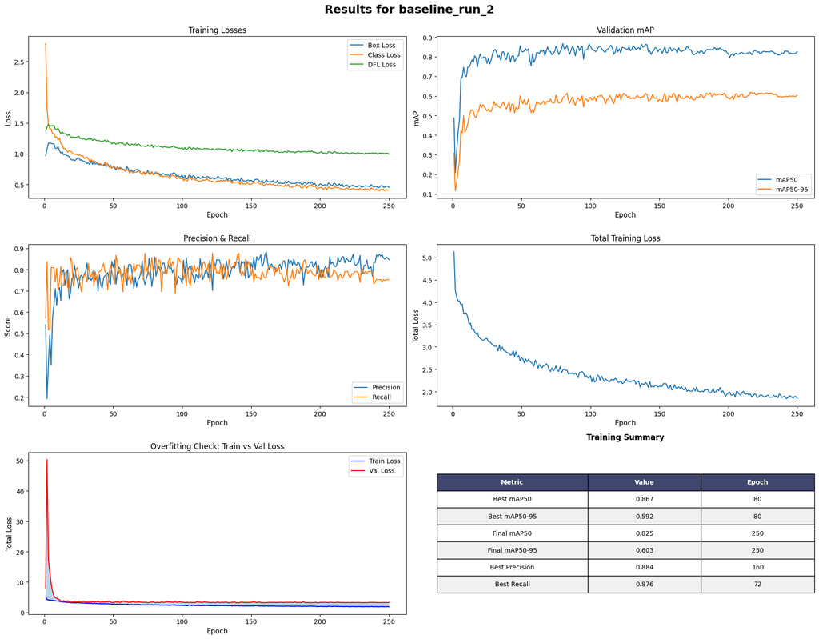

```
============================================================
📈 DETAILED TRAINING STATISTICS
============================================================
Total Epochs: 250

🎯 Best mAP50: 0.8667 (Epoch 79)
🎯 Best mAP50-95: 0.6182 (Epoch 215)

📊 Final Metrics:
   mAP50: 0.8248
   mAP50-95: 0.6026
   Precision: 0.8466
   Recall: 0.7524
============================================================
```

```python
# VISUALIZE
# Run 2 - frozen layers
visualize_training_results(RUNS_DIR)
```

The model stabilized quickly but peaked early at epoch 80 (86.7% mAP50), then gradually declined to 82.5% by epoch 250. The gap between train and validation loss is small and stabilizes early. This still suggests moderate memorization.

Precision is solid at 84.7% (low false positives), but recall dropped to 75.2% - meaning the model misses ~25% of Santas. This is the main weakness compared to baseline_run_1 (which had 85.9% recall). The issue is also lower recall (75% vs 86%) - missing more Santas. The earlier peak (epoch 80 vs 176) and decline suggests we could benefit from adjusting learning rate or regularization.

Frozen layers probaly didn't have the desireed effect of pushing the model into memorization, because we used a larger model (S instead of N, ~11M vs ~3M parameters). The S version has more parameters and a larger capacity. A larger model like YOLOv8-S, with more layers and parameters, has a better ability to generalize and learn more complex features, even when early layers are frozen.

```python
# --- RUN 3: small dataset with small model
model = YOLO(MODEL_N_PATH)

# All disadvantages that force the model to overfit: small dataset, no augmentation, no regularization, frozen early layers
# --- W&B INITIALIZATION ---
wandb.init(
    project='yolov8_santa_train',
    entity='katai',
    config=overfitting_config_3,
    name='overfit_run_3'
)

# --- TRAIN ---
print("🚀 Starting training (designed to overfit) ...")
results = model.train(**overfitting_config_3)

# --- CLEANUP ---
wandb.finish()
print("✅ Training complete!")
```

Finishing previous runs because reinit is set to 'default'.

View run **overfit_run_3** at: https://wandb.ai/katai/yolov8_santa_train/runs/zgl3cksb  
View project at: https://wandb.ai/katai/yolov8_santa_train  
Synced 5 W&B file(s), 0 media file(s), 0 artifact file(s) and 0 other file(s)

Find logs at: `./wandb/run-20260110_134938-zgl3cksb/logs`

Tracking run with wandb version 0.23.1

Run data is saved locally in `/content/drive/My Drive/FHNW/HS_25/DLBS/minichallenge_hs25_object_detection/MC/wandb/run-20260110_134955-74pynpg4`

Syncing run **[overfit_run_3](https://wandb.ai/katai/yolov8_santa_train/runs/74pynpg4)** to [Weights & Biases](https://wandb.ai/katai/yolov8_santa_train) ([docs](https://wandb.me/developer-guide))

View project at https://wandb.ai/katai/yolov8_santa_train

View run at https://wandb.ai/katai/yolov8_santa_train/runs/74pynpg4

```
🚀 Starting training (designed to overfit) ...
Ultralytics 8.3.251 🚀 Python-3.12.12 torch-2.9.0+cu126 CUDA:0 (NVIDIA A100-SXM4-80GB, 81222MiB)
engine/trainer: agnostic_nms=False, amp=True, augment=False, auto_augment=randaugment, batch=15, bgr=0.0, box=7.5, cache=False, cfg=None, classes=None, close_mosaic=0, cls=0.5, compile=False, conf=None, copy_paste=0.0, copy_paste_mode=flip, cos_lr=False, cutmix=0.0, data=small_dataset-3/data.yaml, d…
Overriding model.yaml nc=80 with nc=1

                   from  n    params  module                                       arguments
  0                  -1  1       464  ultralytics.nn.modules.conv.Conv             [3, 16, 3, 2]
  1                  -1  1      4672  ultralytics.nn.modules.conv.Conv             [16, 32, 3, 2]
  2                  -1  1      7360  ultralytics.nn.modules.block.C2f             [32, 32, 1, True]
  3                  -1  1     18560  ultralytics.nn.modules.conv.Conv             [32, 64, 3, 2]
  4                  -1  2     49664  ultralytics.nn.modules.block.C2f             [64, 64, 2, True]
  5                  -1  1     73984  ultralytics.nn.modules.conv.Conv             [64, 128, 3, 2]
  6                  -1  2    197632  ultralytics.nn.modules.block.C2f             [128, 128, 2, True]
  7                  -1  1    295424  ultralytics.nn.modules.conv.Conv             [128, 256, 3, 2]
  8                  -1  1    460288  ultralytics.nn.modules.block.C2f             [256, 256, 1, True]
  9                  -1  1    164608  ultralytics.nn.modules.block.SPPF            [256, 256, 5]
 10                  -1  1         0  torch.nn.modules.upsampling.Upsample         [None, 2, 'nearest']
 11             [-1, 6]  1         0  ultralytics.nn.modules.conv.Concat           [1]
 12                  -1  1    148224  ultralytics.nn.modules.block.C2f             [384, 128, 1]
 13                  -1  1         0  torch.nn.modules.upsampling.Upsample         [None, 2, 'nearest']
 14             [-1, 4]  1         0  ultralytics.nn.modules.conv.Concat           [1]
 15                  -1  1     37248  ultralytics.nn.modules.block.C2f             [192, 64, 1]
 16                  -1  1     36992  ultralytics.nn.modules.conv.Conv             [64, 64, 3, 2]
 17            [-1, 12]  1         0  ultralytics.nn.modules.conv.Concat           [1]
 18                  -1  1    123648  ultralytics.nn.modules.block.C2f             [192, 128, 1]
 19                  -1  1    147712  ultralytics.nn.modules.conv.Conv             [128, 128, 3, 2]
 20             [-1, 9]  1         0  ultralytics.nn.modules.conv.Concat           [1]
 21                  -1  1    493056  ultralytics.nn.modules.block.C2f             [384, 256, 1]
 22        [15, 18, 21]  1    751507  ultralytics.nn.modules.head.Detect           [1, [64, 128, 256]]
Model summary: 129 layers, 3,011,043 parameters, 3,011,027 gradients, 8.2 GFLOPs

Transferred 319/355 items from pretrained weights
Freezing layer 'model.0.conv.weight'
Freezing layer 'model.0.bn.weight'
Freezing layer 'model.0.bn.bias'
Freezing layer 'model.1.conv.weight'
Freezing layer 'model.1.bn.weight'
Freezing layer 'model.1.bn.bias'
Freezing layer 'model.2.cv1.conv.weight'
Freezing layer 'model.2.cv1.bn.weight'
```

[output cut: 1329 more lines]

```
    250/250      1.26G     0.2839     0.4064     0.9496         13        512: 100% ━━━━━━━━━━━━ 2/2 13.8it/s 0.1s
                 Class     Images  Instances      Box(P          R      mAP50  mAP50-95): 100% ━━━━━━━━━━━━ 6/6 10.6it/s 0.6s
                   all        155        105      0.599      0.525      0.535      0.267

250 epochs completed in 0.071 hours.
Optimizer stripped from /content/drive/My Drive/FHNW/HS_25/DLBS/minichallenge_hs25_object_detection/MC/runs/detect/runs/overfit/overfit_run_3/weights/last.pt, 6.3MB
Optimizer stripped from /content/drive/My Drive/FHNW/HS_25/DLBS/minichallenge_hs25_object_detection/MC/runs/detect/runs/overfit/overfit_run_3/weights/best.pt, 6.3MB

Validating /content/drive/My Drive/FHNW/HS_25/DLBS/minichallenge_hs25_object_detection/MC/runs/detect/runs/overfit/overfit_run_3/weights/best.pt...
Ultralytics 8.3.251 🚀 Python-3.12.12 torch-2.9.0+cu126 CUDA:0 (NVIDIA A100-SXM4-80GB, 81222MiB)
Model summary (fused): 72 layers, 3,005,843 parameters, 0 gradients, 8.1 GFLOPs
                 Class     Images  Instances      Box(P          R      mAP50  mAP50-95): 100% ━━━━━━━━━━━━ 6/6 5.1it/s 1.2s
                   all        155        105      0.616      0.551       0.54       0.27
Speed: 0.1ms preprocess, 0.5ms inference, 0.0ms loss, 1.5ms postprocess per image
Results saved to /content/drive/My Drive/FHNW/HS_25/DLBS/minichallenge_hs25_object_detection/MC/runs/detect/runs/overfit/overfit_run_3
```

View run **overfit_run_3** at: https://wandb.ai/katai/yolov8_santa_train/runs/74pynpg4  
View project at: https://wandb.ai/katai/yolov8_santa_train  
Synced 5 W&B file(s), 0 media file(s), 0 artifact file(s) and 0 other file(s)

Find logs at: `./wandb/run-20260110_134955-74pynpg4/logs`

```
✅ Training complete!
```

```python
# --- CONFIGURATION ---
RUNS_DIR = 'runs/detect/runs/overfit/overfit_run_3'
BEST_WEIGHTS_FILENAME = 'best_overfit_3.pt'
OUTPUT_WEIGHTS_NAME = 'weights_overfit_3.pt'

save_weights_to_drive(RUNS_DIR, DRIVE_MODEL_DIR, BEST_WEIGHTS_FILENAME, OUTPUT_WEIGHTS_NAME)
```

```
✅ Best weights saved: best_overfit_3.pt
✅ Last weights saved: weights_overfit_3.pt
```

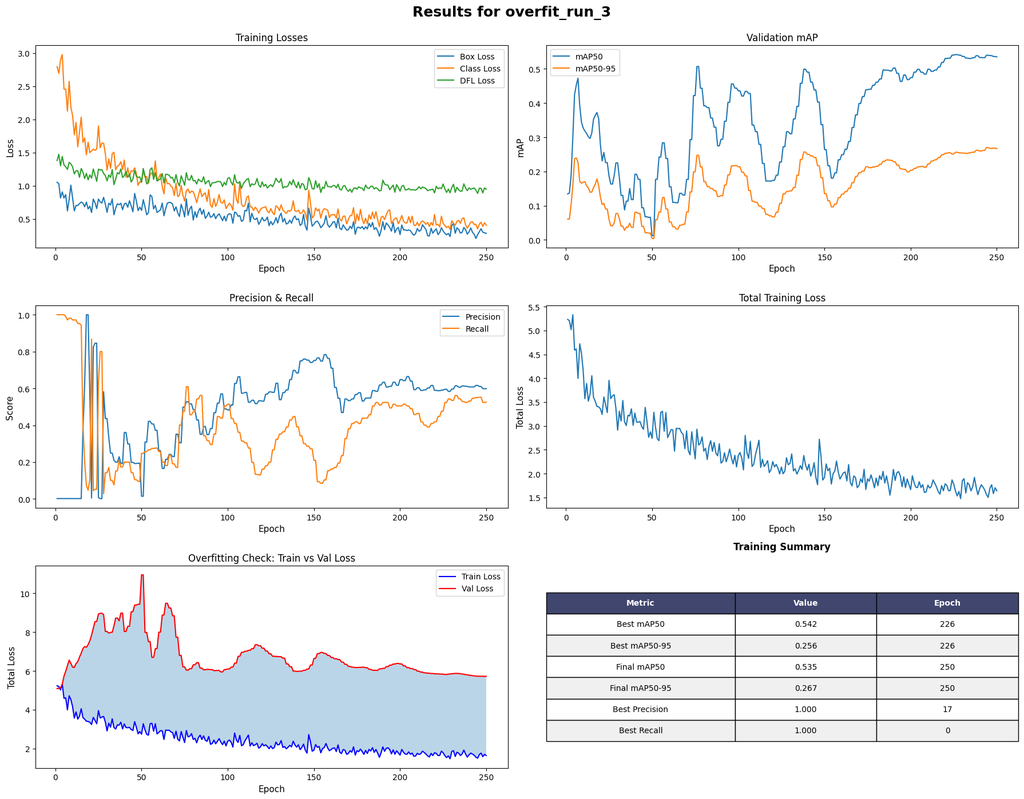

```
============================================================
📈 DETAILED TRAINING STATISTICS
============================================================
Total Epochs: 250

🎯 Best mAP50: 0.5419 (Epoch 225)
🎯 Best mAP50-95: 0.2700 (Epoch 243)

📊 Final Metrics:
   mAP50: 0.5351
   mAP50-95: 0.2667
   Precision: 0.5985
   Recall: 0.5253
============================================================
```

```python
# VISUALIZE
# Run 3 - frozen layers + minimal variety dataset
visualize_training_results(RUNS_DIR)
```

The discrepancy between training and validation loss, as well as the significant drop in mAP50-95 compared to mAP50, indicates that the model is likely memorizing the training data.

In the Overfitting Check, the gap between validation and training is even starker: model fits the training data well but fails to generalize to unseen validation data.

```python
# --- RUN 4: small dataset + larger YOLO s model
model = YOLO(MODEL_S_PATH)

# All disadvantages that force the model to overfit: small dataset, no uagmentation, no regularization, frozen early layers
# --- W&B INITIALIZATION ---
wandb.init(
    project='yolov8_santa_train',
    entity='katai',
    config=overfitting_config_4,
    name='overfit_run_4'
)

# --- TRAIN ---
print("🚀 Starting training (designed to overfit) ...")
results = model.train(**overfitting_config_4)

# --- CLEANUP ---
wandb.finish()
print("✅ Training complete!")
```

Tracking run with wandb version 0.23.1

Run data is saved locally in `/content/drive/My Drive/FHNW/HS_25/DLBS/minichallenge_hs25_object_detection/MC/wandb/run-20260110_140112-qjcpkutx`

Syncing run **[overfit_run_4](https://wandb.ai/katai/yolov8_santa_train/runs/qjcpkutx)** to [Weights & Biases](https://wandb.ai/katai/yolov8_santa_train) ([docs](https://wandb.me/developer-guide))

View project at https://wandb.ai/katai/yolov8_santa_train

View run at https://wandb.ai/katai/yolov8_santa_train/runs/qjcpkutx

```
🚀 Starting training (designed to overfit) ...
Ultralytics 8.3.251 🚀 Python-3.12.12 torch-2.9.0+cu126 CUDA:0 (NVIDIA A100-SXM4-80GB, 81222MiB)
engine/trainer: agnostic_nms=False, amp=True, augment=False, auto_augment=randaugment, batch=15, bgr=0.0, box=7.5, cache=False, cfg=None, classes=None, close_mosaic=0, cls=0.5, compile=False, conf=None, copy_paste=0.0, copy_paste_mode=flip, cos_lr=False, cutmix=0.0, data=small_dataset-3/data.yaml, d…
Overriding model.yaml nc=80 with nc=1

                   from  n    params  module                                       arguments
  0                  -1  1       928  ultralytics.nn.modules.conv.Conv             [3, 32, 3, 2]
  1                  -1  1     18560  ultralytics.nn.modules.conv.Conv             [32, 64, 3, 2]
  2                  -1  1     29056  ultralytics.nn.modules.block.C2f             [64, 64, 1, True]
  3                  -1  1     73984  ultralytics.nn.modules.conv.Conv             [64, 128, 3, 2]
  4                  -1  2    197632  ultralytics.nn.modules.block.C2f             [128, 128, 2, True]
  5                  -1  1    295424  ultralytics.nn.modules.conv.Conv             [128, 256, 3, 2]
  6                  -1  2    788480  ultralytics.nn.modules.block.C2f             [256, 256, 2, True]
  7                  -1  1   1180672  ultralytics.nn.modules.conv.Conv             [256, 512, 3, 2]
  8                  -1  1   1838080  ultralytics.nn.modules.block.C2f             [512, 512, 1, True]
  9                  -1  1    656896  ultralytics.nn.modules.block.SPPF            [512, 512, 5]
 10                  -1  1         0  torch.nn.modules.upsampling.Upsample         [None, 2, 'nearest']
 11             [-1, 6]  1         0  ultralytics.nn.modules.conv.Concat           [1]
 12                  -1  1    591360  ultralytics.nn.modules.block.C2f             [768, 256, 1]
 13                  -1  1         0  torch.nn.modules.upsampling.Upsample         [None, 2, 'nearest']
 14             [-1, 4]  1         0  ultralytics.nn.modules.conv.Concat           [1]
 15                  -1  1    148224  ultralytics.nn.modules.block.C2f             [384, 128, 1]
 16                  -1  1    147712  ultralytics.nn.modules.conv.Conv             [128, 128, 3, 2]
 17            [-1, 12]  1         0  ultralytics.nn.modules.conv.Concat           [1]
 18                  -1  1    493056  ultralytics.nn.modules.block.C2f             [384, 256, 1]
 19                  -1  1    590336  ultralytics.nn.modules.conv.Conv             [256, 256, 3, 2]
 20             [-1, 9]  1         0  ultralytics.nn.modules.conv.Concat           [1]
 21                  -1  1   1969152  ultralytics.nn.modules.block.C2f             [768, 512, 1]
 22        [15, 18, 21]  1   2116435  ultralytics.nn.modules.head.Detect           [1, [128, 256, 512]]
Model summary: 129 layers, 11,135,987 parameters, 11,135,971 gradients, 28.6 GFLOPs

Transferred 349/355 items from pretrained weights
Freezing layer 'model.0.conv.weight'
Freezing layer 'model.0.bn.weight'
Freezing layer 'model.0.bn.bias'
Freezing layer 'model.1.conv.weight'
Freezing layer 'model.1.bn.weight'
Freezing layer 'model.1.bn.bias'
Freezing layer 'model.2.cv1.conv.weight'
Freezing layer 'model.2.cv1.bn.weight'
```

[output cut: 1377 more lines]

```
    250/250      1.74G     0.4179     0.4531      1.016         13        512: 100% ━━━━━━━━━━━━ 2/2 15.4it/s 0.1s
                 Class     Images  Instances      Box(P          R      mAP50  mAP50-95): 100% ━━━━━━━━━━━━ 6/6 10.7it/s 0.6s
                   all        155        105      0.646      0.505      0.572      0.328

250 epochs completed in 0.072 hours.
Optimizer stripped from /content/drive/My Drive/FHNW/HS_25/DLBS/minichallenge_hs25_object_detection/MC/runs/detect/runs/overfit/overfit_run_4/weights/last.pt, 22.5MB
Optimizer stripped from /content/drive/My Drive/FHNW/HS_25/DLBS/minichallenge_hs25_object_detection/MC/runs/detect/runs/overfit/overfit_run_4/weights/best.pt, 22.5MB

Validating /content/drive/My Drive/FHNW/HS_25/DLBS/minichallenge_hs25_object_detection/MC/runs/detect/runs/overfit/overfit_run_4/weights/best.pt...
Ultralytics 8.3.251 🚀 Python-3.12.12 torch-2.9.0+cu126 CUDA:0 (NVIDIA A100-SXM4-80GB, 81222MiB)
Model summary (fused): 72 layers, 11,125,971 parameters, 0 gradients, 28.4 GFLOPs
                 Class     Images  Instances      Box(P          R      mAP50  mAP50-95): 100% ━━━━━━━━━━━━ 6/6 3.8it/s 1.6s
                   all        155        105      0.628      0.676       0.63      0.407
Speed: 0.1ms preprocess, 0.7ms inference, 0.0ms loss, 5.4ms postprocess per image
Results saved to /content/drive/My Drive/FHNW/HS_25/DLBS/minichallenge_hs25_object_detection/MC/runs/detect/runs/overfit/overfit_run_4
```

View run **overfit_run_4** at: https://wandb.ai/katai/yolov8_santa_train/runs/qjcpkutx  
View project at: https://wandb.ai/katai/yolov8_santa_train  
Synced 5 W&B file(s), 0 media file(s), 0 artifact file(s) and 0 other file(s)

Find logs at: `./wandb/run-20260110_140112-qjcpkutx/logs`

```
✅ Training complete!
```

```python
# --- CONFIGURATION ---
RUNS_DIR = 'runs/detect/runs/overfit/overfit_run_4'
BEST_WEIGHTS_FILENAME = 'best_overfit_4.pt'
OUTPUT_WEIGHTS_NAME = 'weights_overfit_4.pt'

save_weights_to_drive(RUNS_DIR, DRIVE_MODEL_DIR, BEST_WEIGHTS_FILENAME, OUTPUT_WEIGHTS_NAME)
```

```
✅ Best weights saved: best_overfit_4.pt
✅ Last weights saved: weights_overfit_4.pt
```

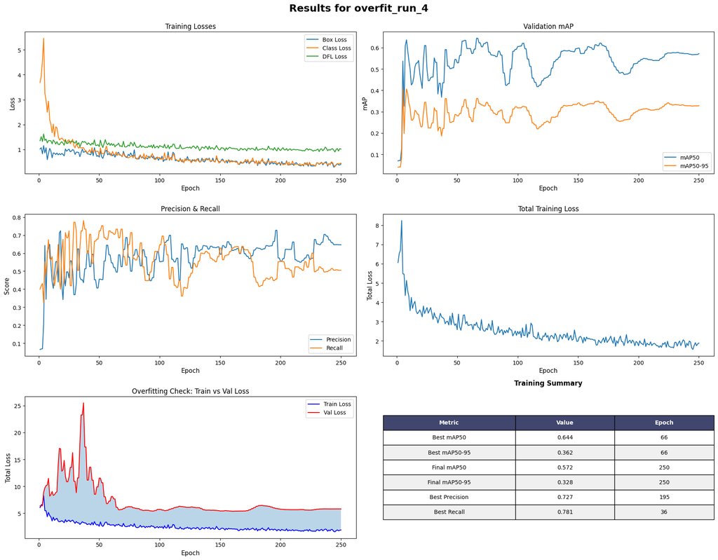

```
============================================================
📈 DETAILED TRAINING STATISTICS
============================================================
Total Epochs: 250

🎯 Best mAP50: 0.6442 (Epoch 65)
🎯 Best mAP50-95: 0.4065 (Epoch 7)

📊 Final Metrics:
   mAP50: 0.5722
   mAP50-95: 0.3284
   Precision: 0.6465
   Recall: 0.5051
============================================================
```

```python
# VISUALIZE
# Run 4 - frozen layers + minimal variety dataset, larger model
visualize_training_results(RUNS_DIR)
```

The "Overfitting Check: Train vs Val Loss" graph shows the training loss dropping significantly while the validation loss stagnates or even rises slightly. Still a strong sign of overfitting, but it appears that larger model (S isntead of N) still generalizes better.

Also mAP50 and mAP50-95:

- N Model: mAP50 = 0.5351
- S Model: mAP50 = 0.5722
- N Model: mAP50-95 = 0.2667
- S Model: mAP50-95 = 0.3284

S model is slightly better at correctly classifying objects in the dataset.

S model is also more confident in its predictions, possibly at the expense of recall.

```python
%pwd
```

```
'/content/drive/MyDrive/FHNW/HS_25/DLBS/minichallenge_hs25_object_detection/MC/runs/detect/runs/overfit'
```

```python
%cd /content/drive/MyDrive/FHNW/HS_25/DLBS/minichallenge_hs25_object_detection/MC
```

```
/content/drive/My Drive/FHNW/HS_25/DLBS/minichallenge_hs25_object_detection/MC
```

## Test Set Run

[figure not shown]

```python
model = YOLO('yolov8_results/best_overfit_3.pt')
data = 'small_dataset-3/test/images/'
results = model(data, verbose=False)

# Loop only through the first 10
fig, axs = plt.subplots(5, 2, figsize=(6, 12))
axs_flat = axs.flatten()
for i, result in enumerate(results[:10]):
    im_array = result.plot()
    ax = axs_flat[i]
    ax.imshow(im_array[..., ::-1])
    ax.set_title(f"Prediction {i+1}", fontsize=10)
    ax.axis('off')
plt.tight_layout()
plt.show()
```

We notice that the modelmisses a few Santas. Poor performance on test set (despite good performance in training) is further supported by the test set metrics.

```python
# Run validation on the test split
metrics = model.val(data=dataset_yaml, split='test')

# Access specific metrics
recall = metrics.results_dict['metrics/recall(B)']
precision = metrics.results_dict['metrics/precision(B)']
mAP50 = metrics.results_dict['metrics/mAP50(B)']
mAP5095 = metrics.results_dict['metrics/mAP50-95(B)']
print(f"Recall: {recall:.2f}")
print(f"Precision: {precision:.2f}")
print(f"mAP50: {mAP5095:.2f}")
print(f"mAP50-95: {mAP5095:.2f}")

# The confusion matrix is automatically saved as 'confusion_matrix.png'
# in the 'runs/detect/val' folder.
```

[output not shown]

```
Checking for plots in: runs/detect/val2

--- Displaying confusion_matrix.png ---
```

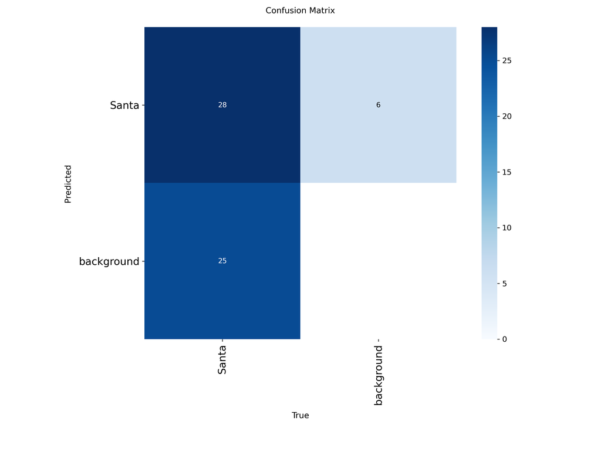

```python
display_yolo_plots('runs/detect/val2', plot_files=['confusion_matrix.png'])
```

```
Checking for plots in: runs/detect/val2

--- Displaying BoxPR_curve.png ---
```

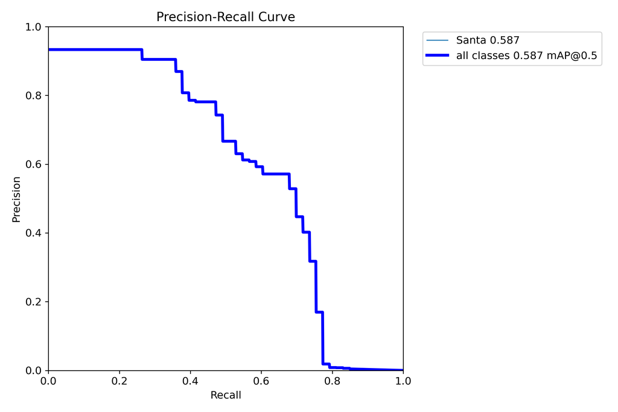

```python
display_yolo_plots('runs/detect/val2', plot_files=['BoxPR_curve.png'])
```

Early on, the precision is very high, but as the recall increases (the model starts predicting more positives), precision drops because more false positives are being included.

```
Checking for plots in: runs/detect/val2

--- Displaying BoxF1_curve.png ---
```

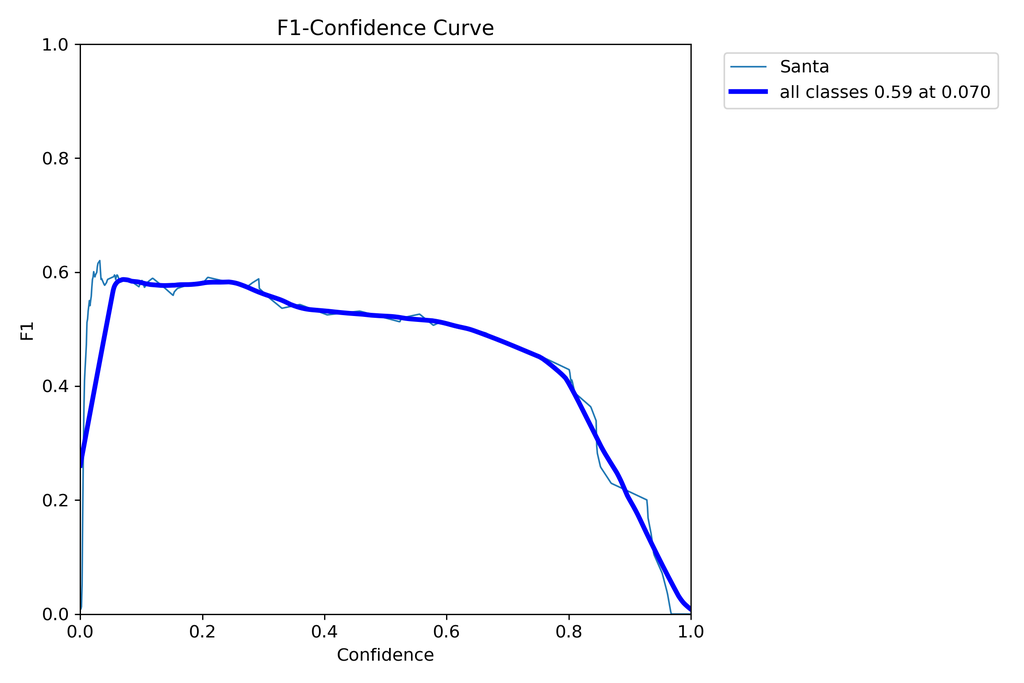

```python
display_yolo_plots('runs/detect/val2', plot_files=['BoxF1_curve.png'])
```

The F1 score tries to balance precision and recall. When the confidence threshold is too low, the model detects many instances (high recall) but might classify some incorrect ones as "Santa" (low precision).

The x-axis epresents the confidence score threshold, which ranges from 0 to 1. The higher the threshold, the more certain the model must be before it classifies an object as positive.

The y-axis shows the F1 score, which combines precision and recall into a single metric. An F1 score of 1 means perfect precision and recall, while 0 means poor performance. The model is fairly confident in predicting "Santa" when the threshold is moderate, but increasing the threshold reduces the model's ability to detect "Santa" (lower recall), causing the F1 score to drop.

Higher thresholds increase the precision (fewer false positives) but reduce recall (more false negatives), which leads to a lower F1 score.

```python
!jupyter nbconvert --to html "/content/drive/MyDrive/FHNW/HS_25/DLBS/minichallenge_hs25_object_detection/MC/02_model_overfit.ipynb.ipynb"
```